# Cleaning and standardising geographic names in R with `prep_geonames()`

A hands-on workshop for systematic geographic name matching

R

Data cleaning

Geospatial

GIS

Author

Mohamed A Yusuf

Published

September 1, 2025

**Important**

*Before you begin, we expect participants to have a basic working knowledge of R. If you are new to R or need a refresher, we recommend reviewing the earlier sessions on [data visualization](https://ammnet.github.io/ammnet-hackathon/posts/data-vis/) and [data wrangling](https://ammnet.github.io/ammnet-hackathon/posts/data-wrangle/).*

*No prior experience with geographic data cleaning is required. However, familiarity with the previous [mapping in R](https://ammnet.github.io/ammnet-hackathon/posts/mapping-r/) session will be useful. In this session, we focus on systematic approaches to geographic name standardisation. You will learn how to detect mismatches, apply string-distance algorithms, use interactive review for ambiguous cases, and build a reusable cache of corrections for future datasets.*

[video not shown]

## Overview

Welcome back! In this post, we turn our attention to one of the most persistent challenges in public health data management: cleaning and standardising geographic names.

We’ll start with a quick look at why mismatched names create problems in analysis, reporting, and decision-making. From there, we’ll walk through a structured approach to name cleaning using the `sntutils::prep_geonames()` function. Along the way, we’ll explore common issues in real datasets, how string-distance algorithms can suggest likely matches, and how to integrate human review only where it is needed.

By the end of this session, you’ll understand how to move from manual, ad hoc fixes to a reproducible workflow that scales from hundreds to tens of thousands of records. You’ll also see how caching, auditing, and match statistics make the process faster, more transparent, and easier to trust.

**Note**

**Learning Objectives**

By the end of this session, you will be able to:

- Understand the nature of geographic name inconsistencies and their impact on data quality.
- Detect and standardise geographic names across multiple datasets.
- Use interactive tools to review and resolve ambiguous matches.
- Handle edge cases by correcting parent-level misassignments before matching.
- Save and re-use corrections through a persistent caching system.
- Validate the quality of name matching with summary statistics.
- Produce simple visualisations to confirm that geographic names align with official boundaries.

## The challenge of name matching

Geographic names are rarely consistent across datasets. The same administrative unit may appear with different spellings, formats, or even linked to the wrong parent. These problems are common in routine health data, survey microdata, and sometimes even in official shapefiles.

When names do not match, joins fail and indicators misalign. This leads to duplicate units in summaries, broken time series when names switch, and wrong denominators in coverage estimates. Analysts spend more time fixing data than analysing it, and programme teams lose trust in the results.

### Two types of problems

It is important to distinguish between two categories:

**1. Name inconsistencies** These are technical issues that can be addressed with systematic cleaning. Examples include:

- Spelling variations (*`Kadunna`* vs *`Kaduna`*).
- Case inconsistencies (*`KANO`* vs *`Kano`*).
- Extra whitespace or hidden characters (*`L agos`* vs *`Lagos`*).
- Abbreviations and aliases (*`FCT`* vs *`Federal Capital Territory`*).
- Language differences (local vs English/French names).
- Parent misassignments (district linked to the wrong region).

**2. Administrative changes** These are structural changes that cannot be solved by name cleaning alone. Examples include:

- New districts created (splits).
- Old districts merged or dissolved.
- Boundaries re-drawn to shift populations between units.
- Renaming linked to political or administrative reforms.

The first set of problems can be handled with a reproducible name-matching workflow. The second set requires authoritative boundary data and programme- level decisions on how to manage new or obsolete units. **This section focuses only on the first category—fixing names**.

### Why manual cleaning fails

Manual cleaning is often the default approach, but it does not scale well as datasets grow. Common issues include:

- **Error-prone.** Fatigue leads to inconsistent fixes.
- **Inconsistent.** Different analysts handle the same issue differently.
- **Non-reproducible.** Corrections exist only in local files or memory.
- **Time-consuming.** Large datasets take hours or days to clean.
- **Lost knowledge.** Corrections disappear when staff leave.
- **Unverifiable.** Hard to track what was changed, when, or by whom.

Some teams try to improve this by coding row-by-row replacements. While more systematic than manual edits, this approach is still limited:

- Hard-coded fixes apply only to one dataset.
- Scripts become brittle and difficult to maintain.
- Overlapping fixes spread across multiple files.
- No single auditable record of decisions exists.

The result is that each new dataset restarts the cycle of ad hoc corrections. The same names are fixed again and again, creating extra effort for analysts, limited reproducibility, and reduced confidence in outputs. Public health data systems need to be auditable—analysts should be able to show *how* a name was standardised, *who* made the decision, and *when* it was applied. Without a structured workflow, results differ each time, cannot be peer-reviewed, and do not build cumulative institutional knowledge.

### Why structured approaches are needed

The challenges of name matching highlight the importance of moving beyond one-off fixes. Ad hoc edits may solve immediate problems but do not create reproducible or scalable workflows. A more systematic approach is needed—one that records decisions, reduces duplication of effort, and makes the process auditable.

Such approaches provide a reproducible way to handle recurring issues in name standardisation. They reduce the need for repeated ad hoc fixes and strengthen confidence in analytical outputs.

## Step-by-step Guide

In this session we present `prep_geonames()`, which illustrates how a structured workflow can be applied in practice.

Key elements include:

- Algorithms to suggest likely matches.
- Interactive review to resolve ambiguous cases.
- A persistent record or cache of accepted decisions.
- Match statistics and exports to support transparency.
- Simple validation checks or visualisations to confirm consistency.

As an example, we use the 2018 DHS dataset to map the modelled percentage of the population without basic water in Nigeria at the `adm2` level. To ensure a reliable join, we align DHS administrative names with the WHO ADM2 shapefile through hierarchy-aware matching, cached decisions, and correction of parent misassignments. This process standardises spelling and boundary labels so that all DHS `adm1` and `adm2` entries match the WHO reference. We validate the result using unmatched-case checks and a map overlay, confirming a complete join with no missing polygons. The workflow is transparent, auditable, and reusable across DHS indicators and other datasets.

### Step 1: Install packages

In the following steps we use `prep_geonames()`, which is part of [sntutils](https://github.com/ahadi-analytics/sntutils/tree/master), an R package by AHADI to support Subnational Tailoring (SNT) of malaria interventions. The package provides a number of helper functions for preparing, cleaning, and analysing data to support decision-making at district level and below.

To install `sntutils` and a number of other packages (`dplyr`, `ggplot2` etc.,), we first need the `pak` package. `pak` makes it easy to install R packages, including development versions from GitHub, along with their dependencies.

```r
# 1) install pak
install.packages("pak")

# 2) install packages
pak::pkg_install(
  c(
    "dplyr",        # data manipulation
    "here",         # for relative file paths
    "ggplot2",      # plotting
    "cli",          # console alerts/messages
    "grid",         # unit sizing for plot theme elements
    "ahadi-analytics/sntutils" # for prep_geoname and other helpers
  ),
  dependencies = TRUE
)
```

### Step 2: Load data

For this example we use modeled data from the 2018 Nigeria DHS, available through the [DHS Local Data Mapping Tool](https://spatialdata.dhsprogram.com/local-data-mapping-tool). Each download includes indicator tables, population counts, uncertainty intervals, and shapefiles. Here we use the Admin 2 tables and shapefiles, specifically the estimates and confidence intervals for the population without basic water. The dataset has been slightly modified with intentional name inconsistencies to demonstrate the cleaning workflow.

```r
# import data
nga_dhs <- sntutils::read(
  here::here("01_data/dhs/Admin2_NGDHS2018Table.xlsx")
) |>
  dplyr::select(
    adm0 = adm0_name,
    adm1 = adm1_name,
    adm2 = adm2_name,
    pop_no_basic_water_value = nobaswatv, # % without basic water
    pop_no_basic_water_ci_lower = nobaswatl, # % without basic water lower CI
    pop_no_basic_water_ci_upper = nobaswatu # % without basic water upper CI
  )

# check the data
dplyr::glimpse(nga_dhs)
```

**NoteOutput**

```
Rows: 774
Columns: 6
$ adm0                        <chr> "Nigeria", "Nigeria", "Nigeria", "Nigeria"…
$ adm1                        <chr> "Abia", "Abia", "Abia", "Abia", "Abia", "A…
$ adm2                        <chr> "Arochukwu", "Bende", "Ikwuano", "Ohafia",…
$ pop_no_basic_water_value    <dbl> 26.20, 27.94, 26.33, 26.05, 27.44, 17.98, …
$ pop_no_basic_water_ci_lower <dbl> 8.92, 11.58, 8.26, 10.87, 7.99, 4.30, 6.24…
$ pop_no_basic_water_ci_upper <dbl> 54.22, 48.40, 49.39, 48.69, 59.50, 42.94, …
```

We also need a reference shapefile of administrative boundaries. For this example we use publicly available WHO ADM2 data, which can be accessed from the [WHO ArcGIS service](https://services.arcgis.com/5T5nSi527N4F7luB/ArcGIS/rest/services/Detailed_Boundary_ADM2/FeatureServer), here we use `sntutils` to download it.

```r
# get/load NGA shapefile (WHO)
nga_shp <- sntutils::download_shapefile(
  country_codes = "NGA",
  admin_level = "adm2",
  dest_path = here::here("01_data/shapefile")
)

# check shapefile
dplyr::glimpse(nga_shp)
```

**NoteOutput**

```
Rows: 774
Columns: 7
$ adm0_code  <chr> "NGA", "NGA", "NGA", "NGA", "NGA", "NGA", "NGA", "NGA", "NG…
$ adm0       <chr> "NIGERIA", "NIGERIA", "NIGERIA", "NIGERIA", "NIGERIA", "NIG…
$ adm1       <chr> "JIGAWA", "ZAMFARA", "BAYELSA", "LAGOS", "ABIA", "BAYELSA",…
$ adm2       <chr> "MIGA", "GUSAU", "NEMBE", "EPE", "UMUAHIA SOUTH", "SAGBAMA"…
$ start_date <date> 2000-01-01, 2000-01-01, 2000-01-01, 2000-01-01, 2000-01-01…
$ end_date   <date> 9999-12-31, 9999-12-31, 9999-12-31, 9999-12-31, 9999-12-31…
$ geom       <MULTIPOLYGON [°]> MULTIPOLYGON (((9.71926 12...., MULTIPOLYGON (…
```

### Step 3: Check matches

Before running any cleaning, inspect how well your dataset matches the reference shapefile (`lookup_data`). Use `sntutils::calculate_match_stats()` to summarise matches by level.

The function is hierarchy-aware. To check or match at `adm2`, you must also provide `adm1` and `adm0`. Column names must be identical in both datasets. The same rule applies at finer levels (e.g., `adm3`, settlements): you must include all higher levels. If your target data use `adm0/adm1/adm2`, your `lookup_data` must use the same names. The same rules apply later in `prep_geonames()`.

```r
# check matches
sntutils::calculate_match_stats(
  nga_dhs,
  lookup_data = nga_shp,
  level0 = "adm0",
  level1 = "adm1",
  level2 = "adm2"
)
```

**NoteOutput**

```
── ℹ Match Summary ─────────────────────────────────────────────────────────────
```

```
! Both sides have unmatched names; see per-level lines below.
```

```
Target data as base N
• adm0 (level0): 1 out of 1 matched
• adm1 (level1): 36 out of 39 matched
• adm2 (level2): 698 out of 774 matched
Lookup data as base N
• adm0 (level0): 1 out of 1 matched
• adm1 (level1): 36 out of 37 matched
• adm2 (level2): 698 out of 774 matched
```

All country names in `nga_dhs` matched those in `nga_shp`. At the `adm1` level, 36 of 37 states matched. At the `adm2` level, 698 of 774 districts matched.

### Step 4: Start matching

#### Step 4.1: Use the shapefile as the reference

We will harmonise the admin names in the target table (`nga_dhs`) to the official shapefile (`nga_shp`) with `sntutils::prep_geonames()`. The function is hierarchy-aware and proceeds top–down (`adm0` → `adm1` → `adm2`). At each level it applies robust text preprocessing (uppercasing, accent removal, whitespace normalisation, punctuation handling) and uses string-distance methods to suggest likely matches within the correct parent context (e.g., `adm2` only compares within the same `adm1`).

Key benefits of `prep_geonames()`:

- Works across up to six levels (`level0`–`level5`).
- Restricts comparisons within parents (contextually correct candidates).
- Caches decisions via `cache_path` so future runs automatically reuse prior corrections and can be shared across analysts for consistency.

```r
# path to cache
cache_path <- here::here("01_data/cache/geoname_cleaning_nga.rds")
unmatched_path <- here::here("01_data/cache/nga_unmatched_adm2.rds")

# 2) Run interactive, hierarchy-based matching
nga_dhs_cleaned <- sntutils::prep_geonames(
  target_df = nga_dhs,   # data to be harmonised
  lookup_df = nga_shp,   # authoritative reference
  level0 = "adm0",
  level1 = "adm1",
  level2 = "adm2",
  cache_path = cache_path,
  interactive = TRUE
)
```

```
Target data as base N
• adm0 (level0): 1 out of 1 matched
• adm1 (level1): 37 out of 37 matched
• adm2 (level2): 774 out of 774 matched
Lookup data as base N
• adm0 (level0): 1 out of 1 matched
• adm1 (level1): 37 out of 37 matched
• adm2 (level2): 774 out of 774 matched
```

You can set `interactive = FALSE` to run in a non‑interactive mode.This ensures headless runs proceed without interactive prompts. When a cache is available, decisions are applied automatically; when it is absent, the code leaves names unchanged and continues.

Below is a short video demonstrating the `prep_geonames()` interface and how it can be used to clean administrative names interactively.

[video not shown]

#### Step 4.2: What gets fixed and how caching helps

`prep_geonames()` typically resolves issues like spelling, spacing, and formatting while honouring the administrative hierarchy.

All interactive decisions are written to the cache (`here::here("01_data/cache/geoname_cleaning_nga.rds")` in this training). The cache records: the admin level, the original name, the chosen replacement from the lookup, the full path of the matched hierarchy, the timestamp, and the decision maker. Re‑running the function on updated data reuses those decisions automatically, which saves time and ensures consistent naming across analysts.

#### Step 4.3: Verify the final join with the shapefile

After harmonisation, confirm that the cleaned table aligns fully with the shapefile structure. Recalculate match stats and check for any remaining unmatched rows.

```r
# 1) Recompute match statistics
sntutils::calculate_match_stats(
  nga_dhs_cleaned,
  lookup_data = nga_shp,
  level0 = "adm0",
  level1 = "adm1",
  level2 = "adm2"
)

# 2) Explicit unmatched check via anti-join
unmatched_after <- dplyr::anti_join(
  dplyr::distinct(nga_dhs_cleaned, adm0, adm1, adm2),
  dplyr::distinct(nga_shp, adm0, adm1, adm2),
  by = c("adm0", "adm1", "adm2")
)

if (nrow(unmatched_after) == 0) {
  cli::cli_alert_success(
    "All admin units in the target now match the shapefile."
  )
} else {
  cli::cli_alert_warning(
    paste0(nrow(unmatched_after), " admin units still need attention.")
  )
  unmatched_after
}
```

**NoteOutput**

```
── ℹ Match Summary ─────────────────────────────────────────────────────────────
```

```
✔ Hierarchies are aligned across data and lookup.
```

```
Target data as base N
• adm0 (level0): 1 out of 1 matched
• adm1 (level1): 37 out of 37 matched
• adm2 (level2): 774 out of 774 matched
Lookup data as base N
• adm0 (level0): 1 out of 1 matched
• adm1 (level1): 37 out of 37 matched
• adm2 (level2): 774 out of 774 matched
```

```
✔ All admin units in the target now match the shapefile.
```

All country names in `nga_dhs` matched those in `nga_shp`. At the `adm1` level, 37 of 37 states matched. At the `adm2` level, 774 of 774 districts matched. Which means our name matching workflow worked.

#### Step 4.4: Review and inspect the cache

With the interactive, stratified matching complete, all units should now align. A small remainder may still be unmatched. Combining geographic constraints with human validation is effective and leaves fewer edge cases.

The cache is both a validation record and a reusable resource. It captures decisions made during the matching process, including confirmation of matches with local knowledge, resolution of ambiguous or misassigned units, alignment with national naming standards, and documentation that supports future harmonisation. The snippet below shows how to read and inspect the saved cache (`cache_path`).

```r
# get cache file
cache_df <- readRDS(cache_path)

# print cache
print(cache_df)
```

**NoteOutput**

| level | name_to_match | replacement | level0_prepped | level1_prepped | level2_prepped | level3_prepped | level4_prepped | created_time | name_of_creator |
| --- | --- | --- | --- | --- | --- | --- | --- | --- | --- |
| level2 | KOTON-KARFE | KOGI | NIGERIA | KOGI | KOGI |  |  | 2025-09-01 10:51:19 UTC | mohamedyusuf |
| level2 | OBOMA NGWA | OBI NWGA | NIGERIA | ABIA | OBI NWGA |  |  | 2025-09-01 10:50:26 UTC | mohamedyusuf |
| level2 | TALATA-MAFARA | TALATA MAFARA | NIGERIA | ZAMFARA | TALATA MAFARA |  |  | 2025-09-01 10:42:32 UTC | mohamedyusuf |
| level2 | BIRNIN-MAGAJI/KIYAW | BIRNIN MAGAJI/KIYAW | NIGERIA | ZAMFARA | BIRNIN MAGAJI/KIYAW |  |  | 2025-09-01 10:42:30 UTC | mohamedyusuf |
| level2 | TARMUWA | TARMUA | NIGERIA | YOBE | TARMUA |  |  | 2025-09-01 10:42:28 UTC | mohamedyusuf |
| level2 | BADE | BARDE | NIGERIA | YOBE | BARDE |  |  | 2025-09-01 10:42:26 UTC | mohamedyusuf |
| level2 | PORT HARCOURT | PORT-HARCOURT | NIGERIA | RIVERS | PORT-HARCOURT |  |  | 2025-09-01 10:42:25 UTC | mohamedyusuf |
| level2 | OPOBO /NKORO | OPOBO/NKORO | NIGERIA | RIVERS | OPOBO/NKORO |  |  | 2025-09-01 10:42:22 UTC | mohamedyusuf |
| level2 | OGU /BOLO | OGU BOLO | NIGERIA | RIVERS | OGU BOLO |  |  | 2025-09-01 10:42:20 UTC | mohamedyusuf |
| level2 | OGBA/ EGBEMA/ NDONI | OGBA/EGBEMA/NDONI | NIGERIA | RIVERS | OGBA/EGBEMA/NDONI |  |  | 2025-09-01 10:42:18 UTC | mohamedyusuf |

[output cut: 62 more lines]

You can reuse this cache on future datasets with the same geography by pointing `cache_path` to the shared file and running with `interactive = FALSE` for headless execution.

### Step 5: Edge case — fix parent level before matching

Sometimes an `adm2` is attached to the wrong `adm1` in the source table. Because `prep_geonames()` restricts candidates within the parent, a wrong parent prevents a match. The fix is to amend the parent level up front (with a reproducible rule) and then run matching.

Below we import a new DHS dataset, similar to Step 2, but with a few edge cases where some `adm2` units are assigned to the wrong `adm1`.

```r
# import edge case data
nga_dhs_edge <- sntutils::read(
  here::here("01_data/dhs/Admin2_NGDHS2018Table_edge.xlsx")
) |>
  dplyr::select(
    adm0 = adm0_name,
    adm1 = adm1_name,
    adm2 = adm2_name,
    pop_no_basic_water_value = nobaswatv, # % without basic water
    pop_no_basic_water_ci_lower = nobaswatl, # % without basic water lower CI
    pop_no_basic_water_ci_upper = nobaswatu # % without basic water upper CI
  )

# check the matching of the stats of the edge case data
sntutils::calculate_match_stats(
  nga_dhs_edge,
  lookup_data = nga_shp,
  level0 = "adm0",
  level1 = "adm1",
  level2 = "adm2"
)
```

**NoteOutput**

```
── ℹ Match Summary ─────────────────────────────────────────────────────────────
```

```
! Both sides have unmatched names; see per-level lines below.
```

```
Target data as base N
• adm0 (level0): 1 out of 1 matched
• adm1 (level1): 36 out of 39 matched
• adm2 (level2): 691 out of 774 matched
Lookup data as base N
• adm0 (level0): 1 out of 1 matched
• adm1 (level1): 36 out of 37 matched
• adm2 (level2): 691 out of 774 matched
```

Let us try to match the names using our cache, setting `interactive = FALSE` and also setting up a path for `unmatched_export_path` so that we can save and inspect any admin names that we could not match.

```r
# 1) set up path to save the unmatched admin names
unmatched_path <- here::here("01_data/cache/nga_unmatched_adm2.rds")

# 2) run interactive, hierarchy-based matching
nga_dhs_edge_cleaned <- sntutils::prep_geonames(
  target_df = nga_dhs_edge, # data to be harmonised
  lookup_df = nga_shp, # authoritative reference
  level0 = "adm0",
  level1 = "adm1",
  level2 = "adm2",
  cache_path = cache_path,
  unmatched_export_path = unmatched_path,
  interactive = FALSE
)
```

**NoteOutput**

```
── ℹ Match Summary ─────────────────────────────────────────────────────────────
```

```
! Both sides have unmatched names; see per-level lines below.
```

```
Target data as base N
• adm0 (level0): 1 out of 1 matched
• adm1 (level1): 37 out of 37 matched
• adm2 (level2): 767 out of 774 matched
Lookup data as base N
• adm0 (level0): 1 out of 1 matched
• adm1 (level1): 37 out of 37 matched
• adm2 (level2): 767 out of 774 matched
```

```
✔ In non-interactive mode. Exiting after matching with cache...
```

```
✔ Unmatched data exported to: '01_data/cache/nga_unmatched_adm2.rds'
```

```
ℹ Exported 7 unmatched rows for column
```

Using the unmatched data export is very helpful in situations like these. It provides a dataset with an `unmatched_column`, the relevant context columns (e.g., `adm2` with its parent levels `adm0` and `adm1`), and additional metadata such as the lookup source, the target dataset, the user who performed the matching, and the timestamp.

Let us import `unmatched_path` to check what these non-matched admins are.

```r
# get cache file
unmatched_df <- readRDS(unmatched_path)

# print cache
print(unmatched_df)
```

**NoteOutput**

| unmatched_column | adm0 | adm1 | adm2 | target_data | lookup_data | created_time | name_of_creator |
| --- | --- | --- | --- | --- | --- | --- | --- |
| adm2 | NIGERIA | BORNO | ETHIOPE WEST | nga_dhs_edge | nga_shp | 2025-09-25T19:05:34Z | jmillar |
| adm2 | NIGERIA | BORNO | IKA NORTH EAST | nga_dhs_edge | nga_shp | 2025-09-25T19:05:34Z | jmillar |
| adm2 | NIGERIA | BORNO | IKA SOUTH | nga_dhs_edge | nga_shp | 2025-09-25T19:05:34Z | jmillar |
| adm2 | NIGERIA | EDO | IKEDURU | nga_dhs_edge | nga_shp | 2025-09-25T19:05:34Z | jmillar |
| adm2 | NIGERIA | EDO | ISIALA MBANO | nga_dhs_edge | nga_shp | 2025-09-25T19:05:34Z | jmillar |
| adm2 | NIGERIA | EDO | MBATOLI | nga_dhs_edge | nga_shp | 2025-09-25T19:05:34Z | jmillar |
| adm2 | NIGERIA | EDO | NGOR-OKPALA | nga_dhs_edge | nga_shp | 2025-09-25T19:05:34Z | jmillar |

We can see seven `adm2` units that we couldn’t match. Let us check these `adm2` in `nga_shp` to confirm they are under the correct `adm1`.

```r
# get names of non‑matched adm2
nonmatched_adm2 <- c(
  "ETHIOPE WEST",
  "IKA NORTH EAST",
  "IKA SOUTH",
  "IKEDURU",
  "ISIALA MBANO",
  "MBATOLI",
  "NGOR-OKPALA"
)

nga_shp |>
  dplyr::filter(adm2 %in% nonmatched_adm2) |>
  dplyr::distinct(adm1, adm2)
```

**NoteOutput**

| adm1 | adm2 |
| --- | --- |
| DELTA | IKA NORTH EAST |
| DELTA | ETHIOPE WEST |
| DELTA | IKA SOUTH |
| IMO | ISIALA MBANO |
| IMO | NGOR-OKPALA |
| IMO | MBATOLI |
| IMO | IKEDURU |

So `ETHIOPE WEST`, `IKA NORTH EAST` and `IKA SOUTH` should be under `DELTA`. Meanwhile, `IKEDURU`, `ISIALA MBANO`, `MBATOLI` and `NGOR-OKPALA` should be under `IMO`.

Let us correct these parent (`adm1`) misassignments (`nga_dhs_edge`) using `dplyr::case_when()`, and then attempt matching using our previous `cache_path`.

```r
# define sets of adm2 that belong to specific adm1
delta_adm2 <- c(
  "ETHIOPE WEST",
  "IKA NORTH EAST",
  "IKA SOUTH"
)

imo_adm2 <- c(
  "IKEDURU",
  "ISIALA MBANO",
  "MBATOLI",
  "NGOR-OKPALA"
)

# 1) fix parent (adm1) misassignments reproducibly
nga_dhs_edge_fixed <- nga_dhs_edge_cleaned |>
  dplyr::mutate(
    adm1 = dplyr::case_when(
      adm2 %in% delta_adm2 ~ "DELTA",
      adm2 %in% imo_adm2 ~ "IMO",
      TRUE ~ adm1
    )
  )

# 2) re-run matching using the cache (non-interactive)
nga_dhs_edge_cleaned <- sntutils::prep_geonames(
  target_df = nga_dhs_edge_fixed,
  lookup_df = nga_shp,
  level0 = "adm0",
  level1 = "adm1",
  level2 = "adm2",
  cache_path = cache_path,
  interactive = FALSE
)
```

**NoteOutput**

```
── ℹ Match Summary ─────────────────────────────────────────────────────────────
```

```
✔ Hierarchies are aligned across data and lookup.
```

```
Target data as base N
• adm0 (level0): 1 out of 1 matched
• adm1 (level1): 37 out of 37 matched
• adm2 (level2): 774 out of 774 matched
Lookup data as base N
• adm0 (level0): 1 out of 1 matched
• adm1 (level1): 37 out of 37 matched
• adm2 (level2): 774 out of 774 matched
```

```
✔ All records matched; process completed. Exiting...
```

After correcting the parent misassignments for seven `adm2` units, we reran the matching non‑interactively using the existing geoname cache. The cached decisions applied cleanly to `nga_dhs_edge_cleaned`, and all units now align with the WHO ADM2 shapefile; both `adm1` and `adm2` report full matches (`unmatched = 0`). With the hierarchy fixed and names harmonised, we can move on to the map‑based validation in Step 6.

### Step 6: Validate with a map (join to shapefile)

As a final validation, join the cleaned table to the shapefile and visualise `pop_no_basic_water_value` by `adm2`. Any grey/NA areas indicate unmatched units.

```r
# 1) join cleaned data to shapefile at adm2
nga_map <- nga_shp |>
  dplyr::left_join(
    nga_dhs_edge_cleaned |>
      dplyr::select(adm0, adm1, adm2, pop_no_basic_water_value),
    by = c("adm0", "adm1", "adm2")
  )

# 2) quick NA check on the indicator
n_na <- sum(is.na(nga_map$pop_no_basic_water_value))
cli::cli_alert_info(
  paste0(n_na, " polygons have no indicator value (NA).")
)

# 3) plot map
p <- ggplot2::ggplot(nga_map) +
  ggplot2::geom_sf(
    ggplot2::aes(fill = pop_no_basic_water_value),
    color = NA,
    linewidth = 0
  ) +
  ggplot2::scale_fill_viridis_c(
    option = "A",
    direction = -1,
    name = "% without basic water"
  ) +
  ggplot2::labs(
    title = "Nigeria: Population without basic water (DHS 2018, adm2)",
    subtitle = "Joined using cleaned names (`nga_dhs_edge_cleaned`)",
    caption = "Source: DHS Local Data Mapping Tool; WHO ADM2 boundaries"
  ) +
  ggplot2::theme_void() +
  ggplot2::theme(
    plot.title = ggplot2::element_text(face = "bold"),
    legend.position = "bottom",
    legend.title.position = "top",
    legend.key.width = grid::unit(1, "cm"),
    legend.justification = c(0, 0)
  )

# save plot
ggplot2::ggsave(
  plot = p,
  filename = "03_outputs/validation_map.png"
)

# check plot
print(p)
```

**NoteOutput**

```
ℹ 0 polygons have no indicator value (NA).
```

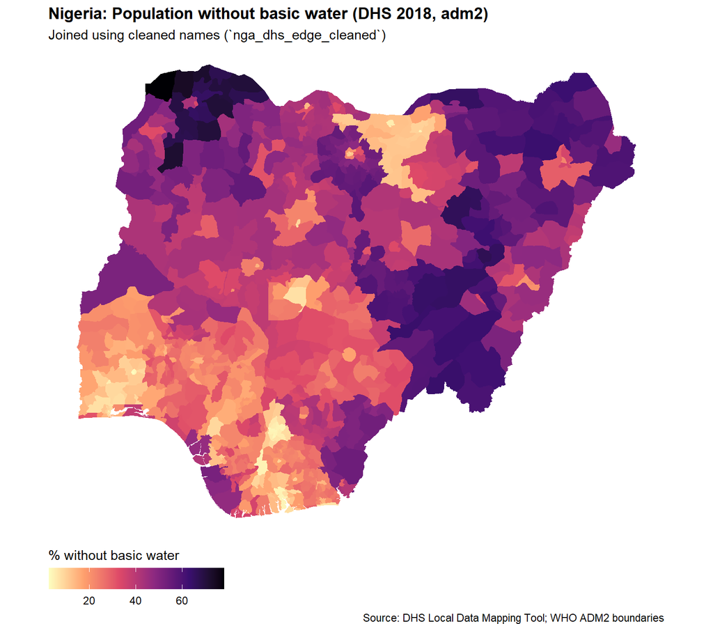

If the workflow is executed correctly, the `NA` count should be 0 and there should be no grey polygons; this indicates that cleaned DHS units align with the shapefile and the indicator values are attached successfully.

## Summary

By following this workflow, you will align DHS administrative names to the WHO ADM2 shapefile using hierarchy‑aware matching, reuse cached decisions, and correct parent misassignments where needed. This should standardise spelling and boundary labelling so that all DHS `adm1` and `adm2` entries match the WHO reference. Final checks using unmatched‑case statistics and a map overlay will confirm whether the join is clean (no `NA` polygons). The approach is reproducible, auditable, and reusable across DHS indicators and other datasets.